# Integral. Výpočet plochy pod krivkou

Daniil Haidukevich

# Motivácia

Pri mnohých praktických problémoch potrebujeme určiť veľkosť oblasti ohraničenej grafom funkcie. Napríklad vo fyzike môže takáto plocha predstavovať prejdenú dráhu, v ekonómii celkový zisk a v štatistike pravdepodobnosť určitej udalosti. Na riešenie podobných úloh sa využíva určitý integrál.

Cieľom projektu je ukázať, ako možno pomocou integrálov vypočítať plochu pod krivkou a ako tento výpočet realizovať v programovacom jazyku R.

# Matematické pozadie

## Primitívna funkcia

Primitívnou funkciou k funkcii $f(x)$ nazývame funkciu $F(x)$, pre ktorú platí

$$F'(x)=f(x).$$

Množinu všetkých primitívnych funkcií zapisujeme pomocou neurčitého integrálu

$$\int f(x),dx = F(x)+C.$$

## Určitý integrál

Určitý integrál na intervale $[a,b]$ zapisujeme

$$\int_a^b f(x),dx.$$

Jeho hodnota predstavuje obsah oblasti medzi grafom funkcie a osou $x$.

Podľa základnej vety integrálneho počtu platí

$$\int_a^b f(x),dx = F(b)-F(a),$$

kde $F$ je primitívna funkcia k $f$.

Riešený príklad

Budeme skúmať funkciu

$$f(x)=x^2$$

na intervale $[-1,2]$.

Analytický výpočet:

$$\frac{8}{3}-\left(-\frac{1}{3}\right)$$

Presná hodnota plochy pod krivkou je teda rovná 3.

# Implementácia v jazyku R

## Výpočet integrálu:

```
3 with absolute error < 3.3e-14
```

Výstup programu potvrdí analyticky získaný výsledok.

## Grafická interpretácia

Nasledujúci graf znázorňuje funkciu $f(x)=x^2$ a oblasť, ktorej obsah vypočítavame pomocou určitého integrálu.

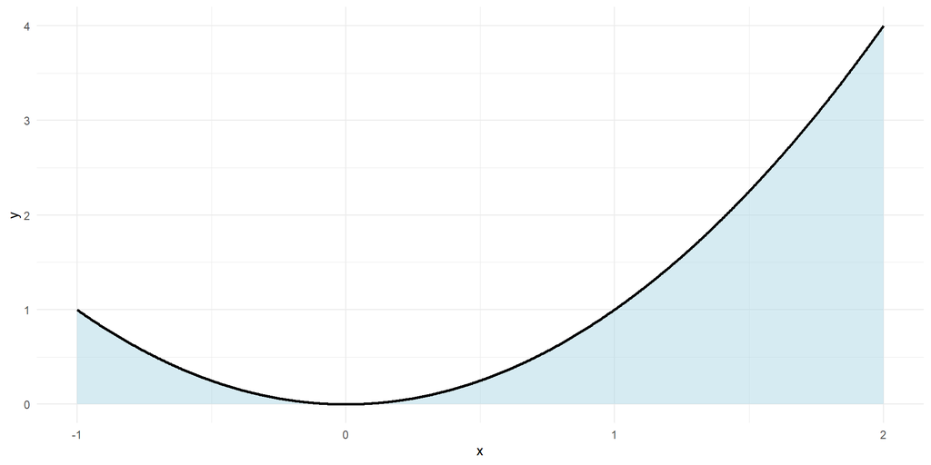

## Aproximácia pomocou obdĺžnikov

Integrál môžeme chápať aj ako limitu súčtu obsahov obdĺžnikov.

Pre interval rozdelený na $n$ častí platí

$$\int_a^b f(x),dx \approx
\sum_{i=1}^{n}f(x_i)\Delta x.$$

## Implementácia:

```
[1] 3
```

```
[1] 2.995505
```

Pri dostatočne veľkom počte obdĺžnikov sú obe hodnoty takmer rovnaké.

# Praktické využitie integrálov

Integrály sa používajú v mnohých oblastiach:

výpočet obsahov a objemov, fyzika (práca, energia, dráha), pravdepodobnosť a štatistika, ekonómia a financie, technické simulácie.

Ich význam preto ďaleko presahuje samotnú matematiku.

# Zhrnutie

Projekt ukázal využitie určitého integrálu pri určovaní plochy pod krivkou. Najprv sme riešili problém analyticky, následne sme použili funkcie jazyka R a nakoniec sme výsledok aproximovali numerickou metódou obdĺžnikov. Získané výsledky potvrdili správnosť teoretických poznatkov a demonštrovali praktické využitie integrálov pri riešení reálnych problémov.